# POS 604: Polimetrics II

## Week 6: Multinomial data/ Multinomial models

There are two major categories of categorical outcomes with more than two possible outcomes:

- Ordered outcomes: Regime type={Democracy, anocracy, autocracy}; education level={High school, undergraduate, Graduate }
- Unordered outcomes: Religion={Protestant, Catholic, Islam, other }; Trade agreement={ WTO, EU, ASEAN }

```python
## Loading stata kernel in jupyter notebook, using python code
import ipystata
from ipystata.config import config_stata
config_stata('C:\Program Files (x86)\Stata14\StataSE-64.exe')
```

For this session, we learn about multinomial models by replicating one of Kathleen Gallagher Cunningham, titled [Understanding strategic choice The determinants of civil war and nonviolent campaign in self-determination disputes](http://journals.sagepub.com/doi/abs/10.1177/0022343313475467)

Read the abstract of the paper; what is the main argument of this paper?

```python
%%stata
*Set the format of printed coeffients and p-values
set cformat %5.2f
set pformat %5.2f
*Load th data:
use "https://github.com/babakrezaee/MethodsCourses/blob/master/POS604_2018/Week6/JPR%20final.dta?raw=true", clear
```

Variable *strategic2* is the strategy choice of self-determination movements.

strategic2 is coded as follwo:

- 0 = conventional politics
- 1= nonviolent campaign
- 2= civil war
- 3= both civil war and nonviolent campaign.

Let's start with summarizing and plotting this variable:

```python
%%stata
des strategic2
display("***************************************************************************************************************")
sum strategic2
display("***************************************************************************************************************")
tab strategic2
display("***************************************************************************************************************")
tab group
display("***************************************************************************************************************")
tab year
```

```
              storage   display    value
variable name   type    format     label      variable label
----------------------------------------------------------------------------------------------------------------------
strategic2      float   %9.0g                 0=conv. 1=nv 2=cw 1000 ever 3=both


    Variable |        Obs        Mean    Std. Dev.       Min        Max
-------------+---------------------------------------------------------
  strategic2 |      5,702    .2306208    .6381616          0          3


    0=conv. |
  1=nv 2=cw |
  1000 ever |
     3=both |      Freq.     Percent        Cum.
------------+-----------------------------------
          0 |      5,023       88.09       88.09
          1 |         62        1.09       89.18
          2 |        598       10.49       99.67
          3 |         19        0.33      100.00
------------+-----------------------------------
      Total |      5,702      100.00


                                  group |      Freq.     Percent        Cum.
----------------------------------------+-----------------------------------
                             Abkhazians |         15        0.26        0.26
                   Aboriginal Taiwanese |         46        0.81        1.07
                            Aboriginals |         46        0.81        1.88
                               Acehnese |         46        0.81        2.68
                                Adzhars |         15        0.26        2.95
                                  Afars |         75        1.32        4.26
                             Afrikaners |         12        0.21        4.47
                              Albanians |         60        1.05        5.52
                             Anjouanese |         31        0.54        6.07
                              Armenains |         15        0.26        6.33
                               Assamese |         46        0.81        7.14
                                  Avars |         15        0.26        7.40
                                Baganda |         44        0.77        8.17
                                Bakongo |         46        0.81        8.98
```

[output cut: 151 more lines]

```
       1993 |        142        2.49       70.33
       1994 |        142        2.49       72.82
       1995 |        142        2.49       75.31
       1996 |        142        2.49       77.80
       1997 |        142        2.49       80.29
       1998 |        142        2.49       82.78
       1999 |        142        2.49       85.27
       2000 |        140        2.46       87.72
       2001 |        140        2.46       90.18
       2002 |        140        2.46       92.63
       2003 |        140        2.46       95.09
       2004 |        140        2.46       97.54
       2005 |        140        2.46      100.00
------------+-----------------------------------
      Total |      5,702      100.00
```

```
(bin=37, start=0, width=.08108108)
```

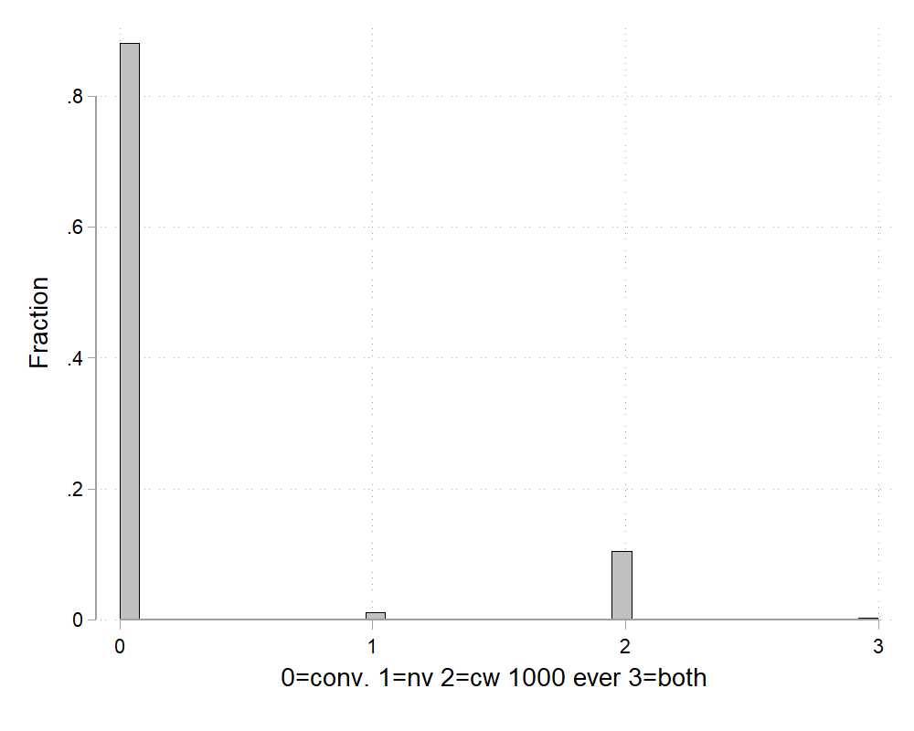

```python
%%stata
hist strategic2, scheme(plotplain) frac
```

This study investigates the effect of a set of variables on the stratgeic choice of self-detemrination movements between conventional politics and different types of contencious politics. The list of regressors:

- democracy: regime type, dummy variable
- instab: Political instability is measured as a three or greater point change in the Polity score of the state in the past two years
- loggdppc: gross domestic product (GDP) per capita (log-transformed), proxy for state capacity
- logSDsize_relative: relative group population
- groupcon: geographic concentration
- kin: transnational kin, whether the SD group has kin in a nearby state.
- logfactions: measure of group fragmentation, which is a logged measure of the number of organizations making demands related to selfdetermination on behalf of the group each year.
- indep: independence demands
- excluded: political exclusion
- avgecdis: economic grievance, the average level of economic discrimination the group faces measuring less to more discrimination.
- logpop: population, log transformed
- last3years_nvcampaign
- last3years_civilwar1000

Formally, we want to estimate the below model: $$strategic2=\alpha_0~democracy+\alpha_1~instab+\alpha_2~loggdppc+\alpha_3~logSDsize_relative+\alpha_4~groupcon+\alpha_5~kin+$$ $$\alpha_6~logfactions+\alpha_7~indep+\alpha_8~excluded+\alpha_9~avgecdis+\alpha_{10}~logpop+\alpha_{11}~last3years\_nvcampaign+\alpha_{12}~last3years\_civilwar1000+\epsilon$$

How do you estimate this model? Let's start with an OLD estimation:

```python
reg strategic2  democracy instab loggdppc logSDsize_relative groupcon kin logfactions indep excluded avgecdis logpop  last3years_nvcampaign last3years_civilwar1000 if active==1, cluster(kgcid)
```

```
  File "<ipython-input-61-236602acb309>", line 1
    reg strategic2  democracy instab loggdppc logSDsize_relative groupcon kin   logfactions indep excluded avgecdis logpop  last3years_nvcampaign last3years_civilwar1000 if active==1, cluster(kgcid)
                 ^
SyntaxError: invalid syntax
```

```python
%%stata
reg strategic2 i.democracy instab loggdppc logSDsize_relative groupcon kin   logfactions indep excluded avgecdis logpop  last3years_nvcampaign last3years_civilwar1000 if active==1, cluster(kgcid)
```

```
Linear regression                               Number of obs     =      2,300
                                                F(13, 88)         =      61.80
                                                Prob > F          =     0.0000
                                                R-squared         =     0.4200
                                                Root MSE          =     .62548

                                            (Std. Err. adjusted for 89 clusters in kgcid)
-----------------------------------------------------------------------------------------
                        |               Robust
             strategic2 |      Coef.   Std. Err.      t    P>|t|     [95% Conf. Interval]
------------------------+----------------------------------------------------------------
            1.democracy |       0.06       0.10     0.59    0.56        -0.14        0.26
                 instab |      -0.06       0.05    -1.12    0.27        -0.17        0.05
               loggdppc |      -0.08       0.04    -2.25    0.03        -0.16       -0.01
     logSDsize_relative |       0.09       0.04     2.26    0.03         0.01        0.17
              groupcon2 |      -0.05       0.06    -0.82    0.41        -0.17        0.07
                    kin |       0.16       0.10     1.57    0.12        -0.04        0.37
            logfactions |       0.17       0.05     3.14    0.00         0.06        0.27
      independencedummy |       0.23       0.09     2.56    0.01         0.05        0.41
               excluded |       0.24       0.10     2.52    0.01         0.05        0.43
               avgecdis |       0.08       0.04     2.15    0.03         0.01        0.16
                 logpop |      -0.07       0.04    -1.60    0.11        -0.16        0.02
  last3years_nvcampaign |       0.65       0.13     5.13    0.00         0.40        0.90
last3years_civilwar1000 |       1.16       0.13     9.15    0.00         0.91        1.42
                  _cons |       0.41       0.50     0.81    0.42        -0.59        1.41
-----------------------------------------------------------------------------------------
```

```
  Variables that uniquely identify margins: democracy
```

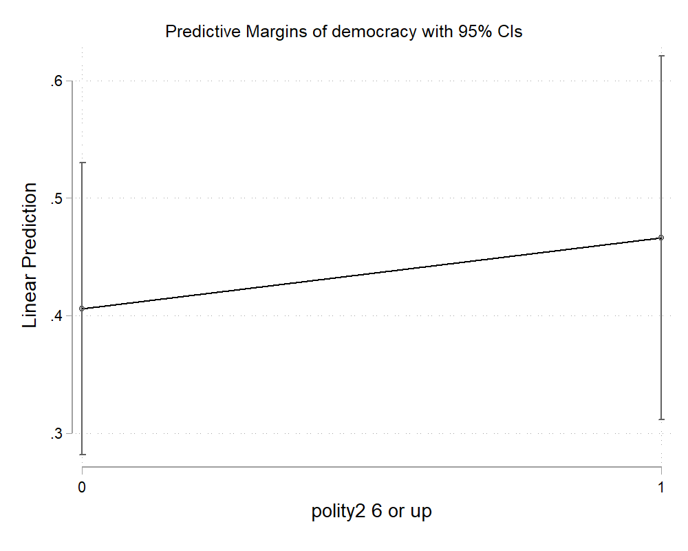

```python
%%stata
quietly margins i.democracy
marginsplot, scheme(plotplain)
```